# Voice Emission Model

Jonathan Siliézar

01/07/2021

# Introduction

Dans le cadre de mon stage intitulé “Modélisation numérique des paysages sonores urbains” à l’Université Gustave Eiffel, un modèle d’émission de la voix est proposée à partir d’une base de données constituée des extraits audio récupères de la plateforme open access FREESOUND, BBC Sounds et même des enregistrements faits par moi même; ainsi comme des avancements faits par l’ancien stagiaire du laboratoire L. Jacquesson. L’objectif de ce document est de présenter les differentes étapes à suivre pour la géneration des cartes de bruit dynamiques (en temps) à partir des données spatiales d’une zone d’étude (Centre ville du Nantes).

Le workflow de travail est illustré par la figure suivante:

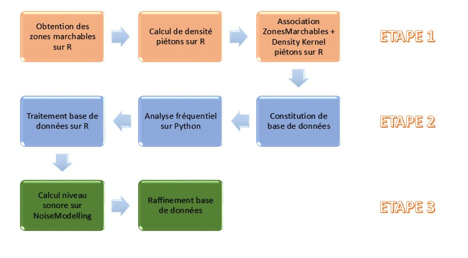

Workflow

# Set working directory and libraries

On commence par definir le repertoire où on va trouver nos fichiers ainsi que les libraries à utiliser

```r
setwd("I:/Documentos/5A/Stage Inge/Rapport Stage")
library(geojsonR)
library(ggplot2)
library(sf)
library(leaflet)
library(raster)
library(rgdal)
library(stars)
library(dplyr)
library(sp)
library(raster)
library(lwgeom)
library(units)
library(data.table)
```

# Obtention des zones marchables (SQL)

La première étape consiste à définir une zone d’étude. Pour notre cas, j’ai choisi le centre ville de Nantes car elle s’avère d’une zone très dynamique en termes des commerces et passage des piétons. Une fois la zone d’étude est définie, on procède à extraire l’information geospatiale des fichiers pour le traitement sur SQL (Fonctions fournies par Léo Jacquesson). Les fichiers ont été récuperés du site GeoFabrik (open access) en format GeoJSON. Ces fichiers ont été traités sur SQL grace aux fonctions créés par L. Jacquesson avec lesquelles on peut génerer un buffer autour des zones marchables où il est possible de placer des piétons. Ces fonctions peuvent être aussi utilisées pour localiser des fontaines ainsi que des zones vertes où on trouve des arbres et oiseaux (En cas où on s’intéresse à un modèle d’emission des fontaines ou oiseaux).Une fois le traitement de ces couches est abouti, on récupère une couche “ZonesMarchables” dont on va s’appuyer dans la suite pour génerer notre couche des points sources. La couche “ZonesMarchables” est répresentée ci-dessous:

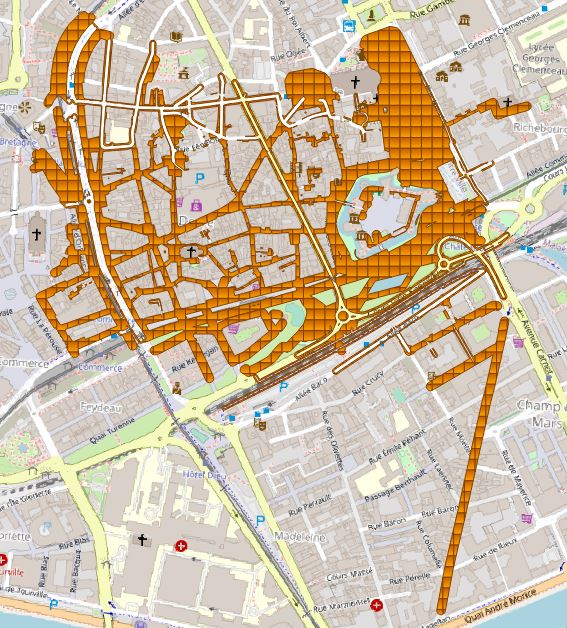

ZonesMarchables

# Calcul de densité piétons

Une fois on obtient une layer avec des polygones où on peut placer nos points sources (piétons), on procède à calculer la densité des piétons dans la zone d’intérêt. Cela nous permettra de obtenir une estimation du nombre de piétons repartis dans la zone d’étude (Zone marchable) et ainsi de générer une couche des points sources qui correspond au nombre de piétons présents dans cette zone. On aura alors besoin des éléments suivants:

- Spatial Density Kernel
- Layer Boutiques (GeoFabrik)
- Layer Restaurants (GeoFabrik)
- Layer Tramway (GeoFabrik)
- Layer ZPB_Explode (Fonction SQL)

# Spatial Density Kernel

Pour effectuer le calcul de densité des points, il est nécessaire de calculer le **kernel de densité**

> Un kernel de densité est une manière non-paramétrique d’estimer la fonction de densité de probabilité d’une variable aléatoire

La fonction pour effectuer ce calcul peut-être localisée dans le lien suivant:

[GitHub](https://github.com/r-spatial/sf/issues/1201)

```r
st_kde <- function(points,cellsize, bandwith, extent = NULL){
  require(MASS)
  require(raster)
  require(sf)
  if(is.null(extent)){
    extent_vec <- st_bbox(points)[c(1,3,2,4)]
  } else{
    extent_vec <- st_bbox(extent)[c(1,3,2,4)]
  }

  n_y <- ceiling((extent_vec[4]-extent_vec[3])/cellsize)
  n_x <- ceiling((extent_vec[2]-extent_vec[1])/cellsize)

  extent_vec[2] <- extent_vec[1]+(n_x*cellsize)-cellsize
  extent_vec[4] <- extent_vec[3]+(n_y*cellsize)-cellsize

  coords <- st_coordinates(points)
  matrix <- kde2d(coords[,1],coords[,2],h = bandwith,n = c(n_x,n_y),lims = extent_vec)
  raster(matrix)
}
```

# Importation des tables

On importe les tables mentionnés ci-dessus à partir de lesquelles on produira notre carte de densité:

```r
boutiques <- st_read("BOUTIQUES.shp")
restaurants <- st_read("RESTAURANTS.shp")
tramway <- st_read("TRAMWAY.shp")
zonepieton <- st_read("ZPB_EXPLODE2.shp")
extent_zone <- st_bbox(zonepieton)[c(1,3,2,4)]
```

# Visualization des layers

*Ces layers contiennent la position de chaque boutique, restaurant et arrêt de tramway dans la zone d’étude*

On peut visualizer l’information contenue par chacune de ces layers:

```r
boutiques84 <- st_transform(boutiques,4326)

leaflet(boutiques84) %>%
  addTiles() %>%
  addMarkers()
```

[interactive chart not shown]

```r
resto84 <- st_transform(restaurants,4326)

leaflet(resto84) %>%
  addTiles() %>%
  addMarkers()
```

[interactive chart not shown]

```r
tramway84 <- st_transform(tramway,4326)

leaflet(tramway84) %>%
  addTiles() %>%
  addMarkers()
```

[interactive chart not shown]

# Estimation de densité

Une fois les layers son importées, on peut démarrer avec le calcul du kernel de densité, pour cela on utilise la fonction **st_kde**

```r
#Calcul du kernel densité
boutiques_dens <- st_kde(boutiques,20,400,extent = extent_zone)
restaurants_dens <- st_kde(restaurants,20,400,extent = extent_zone)
tramway_dens <- st_kde(tramway,20,400,extent = extent_zone)

#On donne les attributs de projection aux raster de densité crées
projection(boutiques_dens) <- projection(boutiques)
projection(tramway_dens) <- projection(tramway)
projection(restaurants_dens) <-  projection(restaurants)
```

# Modèle de densité des piétons

Le travail fourni par Léo Jacquesson propose un modèle de densité avec les coefficients suivants:

```r
#Coefficients du modèle
coeff_boutiques <-5593
coeff_resto <-3042
coeff_tram <- 36922
```

A partir de ces coefficients, on démarre le calcul pour obtenir une layer avec le nombre de piétons par cellule

```r
# on aligne les raster si jamais leur origine sont différentes
template<- projectRaster(to = restaurants_dens, from= boutiques_dens, alignOnly=TRUE)

#template is an empty raster that has the projected extent of r2 but is aligned with r1 (i.e. same resolution, origin, and crs of r1)
resto_aligned<- projectRaster(from = restaurants_dens, to= template)
tram_aligned <-  projectRaster(from=tramway_dens, to=template)

# mosaic fait la somme des rasters
merged_rasters<- mosaic(coeff_boutiques*boutiques_dens,coeff_resto*resto_aligned, coeff_tram*tram_aligned, fun=sum, na.rm=TRUE)

# vectorisation du raster mergé
mailles_densiy_vec_sf <-  rasterToPolygons(merged_rasters, dissolve = F)
mailles_densiy_vec_sf <- st_as_sf(mailles_densiy_vec_sf)
mailles_densiy_vec_sf <- st_transform(mailles_densiy_vec_sf, 2154)

# cellules dans zone marchable
ZonesMarchables <- st_intersection(zonepieton, mailles_densiy_vec_sf)
```

# Filtrage des cellules

On peut observer que dans **ZonesMarchables** il y a des cellules trop fines et trop petites où, pour le moment, on ne veut pas placer des points sources. Alors on va filtrer ces cellules en définissant un seuil de **compacité**

> La compacité est le rapport entre l’air et le perimétre de notre cellule

On peut utiliser la librarie *lwgeom* pour le calcul du perimétre

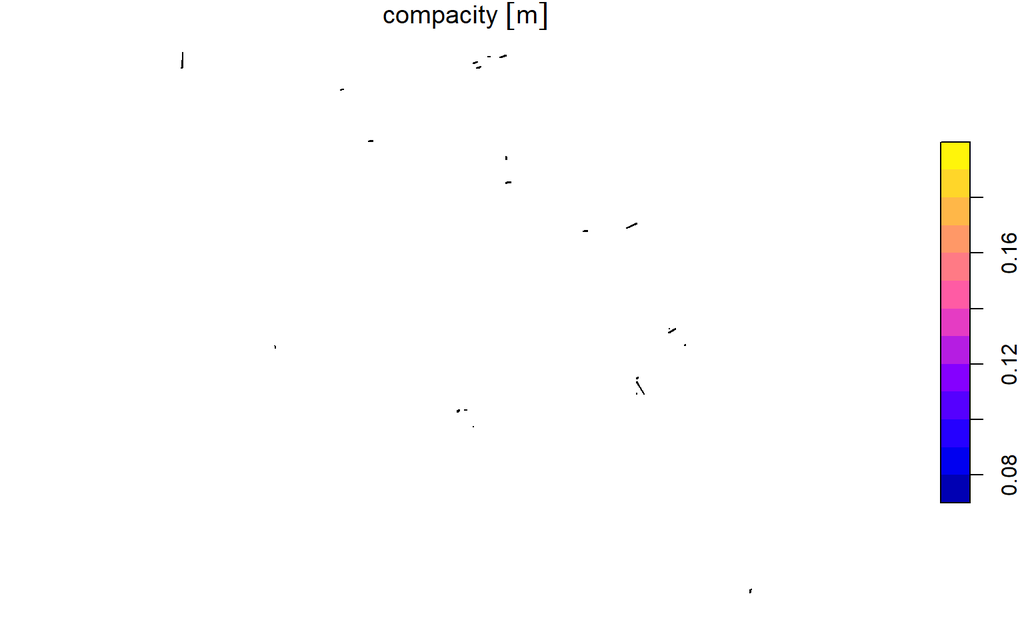

```r
# On définit un objet en unités "metres carrés"  avec une valeur , ici 1

area_threshold <-  as_units(1,"m^2")

 # On applique ce seuil avec un filtre
ZonesMarchables <- ZonesMarchables %>%  filter(st_area(.) > area_threshold)

# Calcul de la compacité (non normalisée)
ZonesMarchables$compacity <-  st_area(ZonesMarchables)/st_perimeter(ZonesMarchables)

# Seuil
compacity_threshold <-  as_units(0.2, "m")

# Affichage pour voir l'aspect des cellules
une_zone_fine <- ZonesMarchables %>%  filter(compacity < compacity_threshold)
plot(une_zone_fine[, "compacity"])
```

```r
# Filtrage des cellules au dessus du seuil de compacité
ZonesMarchables <-  ZonesMarchables %>%  filter(compacity > compacity_threshold)
```

Ensuite on procéde à affecter les cellules filtrées avec le nombre de piétons correspondant

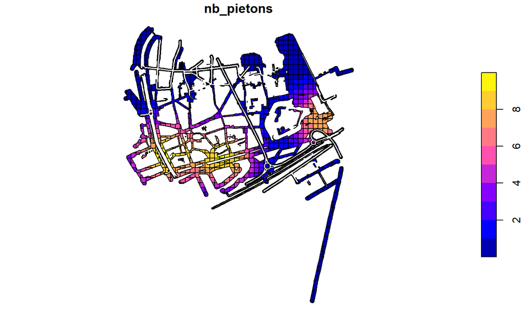

```r
# affectation du nombre de piétons par cellules
MAX_PIETONS <- 10
ZonesMarchables$nb_pietons <-  (ZonesMarchables$layer - min(ZonesMarchables$layer)) / (max(ZonesMarchables$layer)- min(ZonesMarchables$layer))
ZonesMarchables$nb_pietons <- ZonesMarchables$nb_pietons * MAX_PIETONS
ZonesMarchables$nb_pietons <- round(ZonesMarchables$nb_pietons)
plot(ZonesMarchables["nb_pietons"])
```

# Echantillonage spatial des points

La prochaine étape une fois qu’on a généré une layer avec l’information sur le nombre de piétons **ZonesMarchables** c’est d’échantilloner spatialement les points sources dans cette layer, pour cela on a 3 alternatives:

- Première façon: Boucle for (Temps de calcul très elevé)

```r
cells_to_fill <- ZonesMarchables[as.numeric(st_area(ZonesMarchables))  > 1,]
# On ne remplit pas les cellules avec une densité 0
cells_to_fill <- cells_to_fill[cells_to_fill$nb_pietons > 0 ,]
plot(cells_to_fill["nb_pietons"])
sourcesPietons <-  list()
for (i in 1:nrow(cells_to_fill)){
  c <-cells_to_fill$geometry[i]
  n <- cells_to_fill$nb_pietons[i]
  cat("maille", i,": ", n, "points dans" , st_area(c), "m?\n")
  pts <- st_sample(c,n, type="regular") %>% st_sf()
  if(nrow(pts)>0){
    sourcesPietons[[i]] <- pts
  }
}
SourcesPietons1 <- rbindlist(sourcesPietons)
SourcesPietons1 <- SourcesPietons1 %>% st_sf()
#affichage simple
plot(cells_to_fill$geometry, lwd=0.1)
plot(SourcesPietons1, add=T, cex=0.1, col="orange")
dev.off()
```

- Déuxième façon: Intersection entre raster de densité et point sources (Temps de calcul moderé)

```r
SourcesPietons2 <-  st_sample(cells_to_fill$geometry, size=cells_to_fill$nb_pietons, type="regular")
#intersection entre sources et rasters de densités
dens_boutiques <-  extract(boutiques_dens, sourcesPietons2 %>% as_Spatial())
dens_tramway <-  extract(tramway_dens, sourcesPietons2 %>% as_Spatial())
dens_restaurants <- extract(restaurants_dens, sourcesPietons2 %>% as_Spatial())
# affectation des attributs
SourcesPietons2$dens_boutiques <-  dens_boutiques
SourcesPietons2$dens_traway <-  dens_tramway
SourcesPietons2$dens_restaurants <-  dens_restaurants
```

> Fusion entre 2 data frames où on obtient toutes les lignes de la table à gauche et toutes les lignes correspondantes de la deuxième table

```r
SourcesPietons3 <- ZonesMarchables %>% filter(nb_pietons > 0) %>% st_centroid() #Filtrage des points avec une valeur = 0
```

# Constitution de base de données

Une fois que la couche **ZonesMarchables** est génerée avec l’échantillonage spatial de points, on s’intéresse à constituer une base de données sur laquelle on appliquera une analyse fréquentielle pour mettre en evidence les caractéristiques de la voix parlée sur différentes situations: à 1 personne, 2 personnes, 3 personnes, etc. L’intéret de cette étape est d’obtenir un spectrum contenant l’information fréquentielle de chaque extrait d’audio découpée en pas du temps pour produire une carte de bruit dynamique dans la dernière étape. **ZonesMarchables** sera liée à cette base de données par le nombre de piétons, ceci nous permettra d’affecter les cellules de **ZonesMarchables** et de génerer une couche **SourcesPietons** avec une grille de points représentant les piétons en fonction de la densité sur chaque cellule.

Nous commençons par importer les tables à traiter. Nous avons choisi de suivre le diagramme suivant pour le traitement des bases de données, où **T1** est la table contenant les spectrums des fichiers audio obtenue de Python, **T2** contient l’information de la base de données et **T3** contient les données géographiques de points sources:

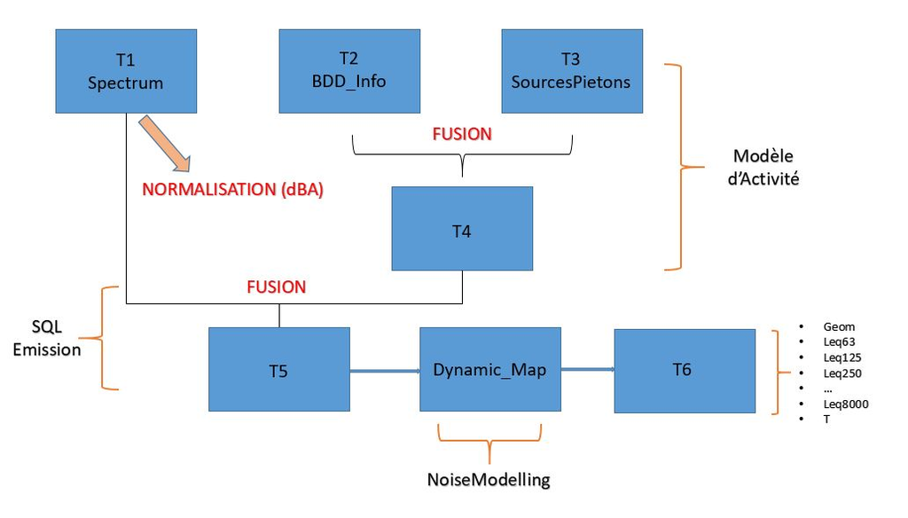

TraitemenBDD

```r
#Importation des BDD et couches à traiter
T1 <-read.csv("Spectrums_500ms.csv", head=TRUE, sep=";")
T2 <- read.csv("BDD_Info.csv", head = TRUE, sep=";")
T3 <- st_read("sourcesPietonsPaul2.shp")

Ponderation_A <-read.csv("PonderationA.csv", head=TRUE, sep=";")
Ponderation_A <- gsub(",", ".", Ponderation_A) #Correction du format de la table
Ponderation_A <- as.numeric(Ponderation_A) #Conversion a numerique
Leq_table <-read.csv("Leq_table.csv", head=TRUE, sep=";")
```

> *ID_g* est l’ID géneral des fichiers audio par pas du temps. Il depend de la durée que nous avons choisi à l’entrée du calcul sur Python

```r
#Fusion T1+T4 pour sortir T5
setnames(T4, "ID", "ID_File") #On renomme la colonne pour pivoter sur ID_g
id <- seq(1, nrow(T4), 1)
T4 <- cbind(id,T4)

T5 <- merge(T4,T1,by="ID_File")
```

[output not shown]

A partir de ce point, nous pasons sur **NoiseModelling** pour la suite.